# Take-home Excercise 1

# 1.0 Introduction

This is a visual analysis project which uses the data from [VAST Challenge 2022](https://vast-challenge.github.io/2022/).

- **Data: Participants.csv**: Contains information about the residents of Engagement,OH that have a greed to participate in this study.
- Packages: tidyverse, ggdist, gghalves The data is processed by using appropriate **tidyverse** family of packages and the statistical graphics is prepared using **ggplot2** and its **extensions**.

```r
packages = c('tidyverse', 'ggdist', 'ggridges',
             'patchwork', 'ggthemes', 'hrbrthemes',
             'ggrepel', 'ggforce')
for(p in packages){
  if(!require(p, character.only = T)){
    install.packages(p)
  }
  library(p, character.only = T)
}
```

# Read-in data

- participantId: int
- householdSize: int
- haveKids(boolean):whether there arechildrenlivingintheparticipant’shousehold
- age: (integer):participant’s age in years at the start of the study
- educationLevel(stringfactor):the participant’s education level,one of: {“Low”,“HighSchoolOrCollege”,“Bachelors”,“Graduate”}
- interestGroup(char):a char representing the participant’s stated primary interest
- joviality(float):a value ranging from[0,1] indicating the participant’s overall happiness level at the start of the study

```r
# Reading the csv file as a tbl_df
participants_data <- read_csv("./data/Participants.csv")
# Inspecting the structure of the dataset
# str(participants_data)
str(participants_data)
```

```
## spec_tbl_df [1,011 × 7] (S3: spec_tbl_df/tbl_df/tbl/data.frame)
##  $ participantId : num [1:1011] 0 1 2 3 4 5 6 7 8 9 ...
##  $ householdSize : num [1:1011] 3 3 3 3 3 3 3 3 3 3 ...
##  $ haveKids      : logi [1:1011] TRUE TRUE TRUE TRUE TRUE TRUE ...
##  $ age           : num [1:1011] 36 25 35 21 43 32 26 27 20 35 ...
##  $ educationLevel: chr [1:1011] "HighSchoolOrCollege" "HighSchoolOrCollege" "HighSchoolOrCollege" "HighSchoolOrCollege" ...
##  $ interestGroup : chr [1:1011] "H" "B" "A" "I" ...
##  $ joviality     : num [1:1011] 0.00163 0.32809 0.39347 0.13806 0.8574 ...
##  - attr(*, "spec")=
##   .. cols(
##   ..   participantId = col_double(),
##   ..   householdSize = col_double(),
##   ..   haveKids = col_logical(),
##   ..   age = col_double(),
##   ..   educationLevel = col_character(),
##   ..   interestGroup = col_character(),
##   ..   joviality = col_double()
##   .. )
##  - attr(*, "problems")=<externalptr>
```

# Joviality vs educationLevel

As the educationLevel goes up from highSchoolOrCollege to graduate, people are generally happier.

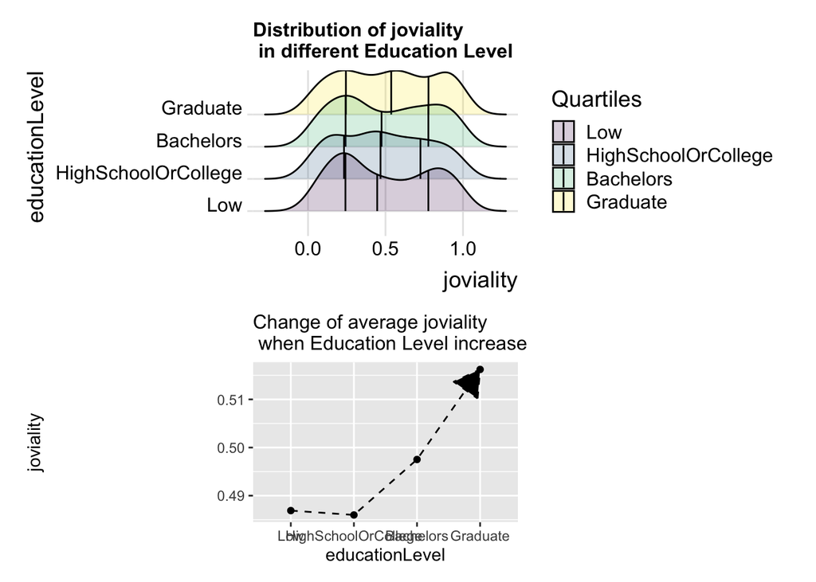

```r
participants_data$educationLevel <-factor(participants_data$educationLevel,ordered=TRUE,levels=c('Low','HighSchoolOrCollege',"Bachelors","Graduate"))
agg_happy <- participants_data %>%
  select(c("educationLevel","joviality")) %>%
  group_by(educationLevel) %>%
  summarise(joviality=mean(joviality))

happy_sorted <- agg_happy %>%
  arrange(desc(educationLevel))

p1=ggplot(participants_data, aes(x = joviality, y = educationLevel, fill = educationLevel)) +
  geom_density_ridges(geom = "density_ridges_gradient",
                      calc_ecdf = TRUE,
                      quantiles = 4,
                      quantile_lines = TRUE,
                      alpha = .2) +
  theme_ridges() +
  scale_fill_viridis_d(name = "Quartiles")+
  ggtitle("Distribution of joviality \n in different Education Level")+
  theme(plot.title = element_text(size = 12))
p2=ggplot(data=happy_sorted,
      aes(y = joviality,
      x= educationLevel,
      group=1)) +
  geom_line(linetype = "dashed",color='black',arrow = arrow(type = "closed"))+
  geom_point(stat = "identity",
             position = "identity")+
  ggtitle("Change of average joviality \n when Education Level increase")+
  theme(plot.title = element_text(size = 12))
p1/p2
```

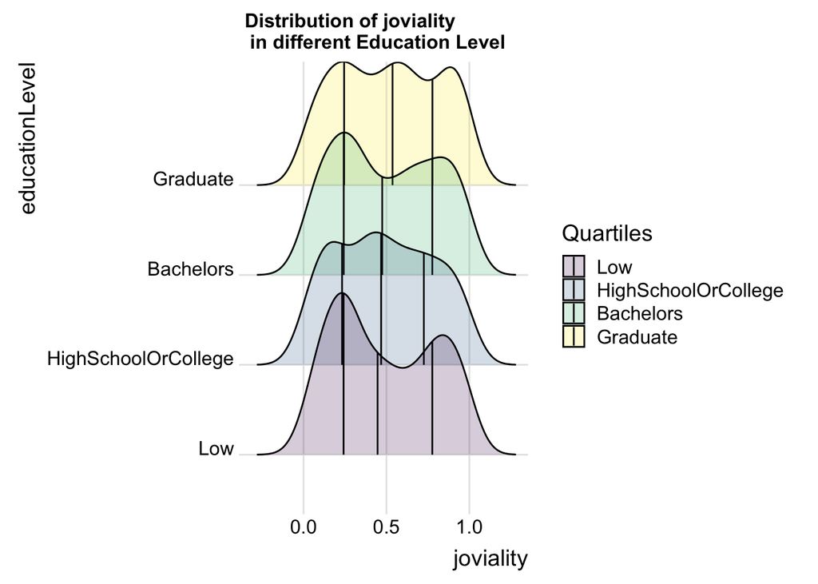

```r
ggplot(participants_data, aes(x = joviality, y = educationLevel, fill = educationLevel)) +
  geom_density_ridges(geom = "density_ridges_gradient",
                      calc_ecdf = TRUE,
                      quantiles = 4,
                      quantile_lines = TRUE,
                      alpha = .2) +
  theme_ridges() +
  scale_fill_viridis_d(name = "Quartiles")+
  ggtitle("Distribution of joviality \n in different Education Level")+
  theme(plot.title = element_text(size = 12))
```

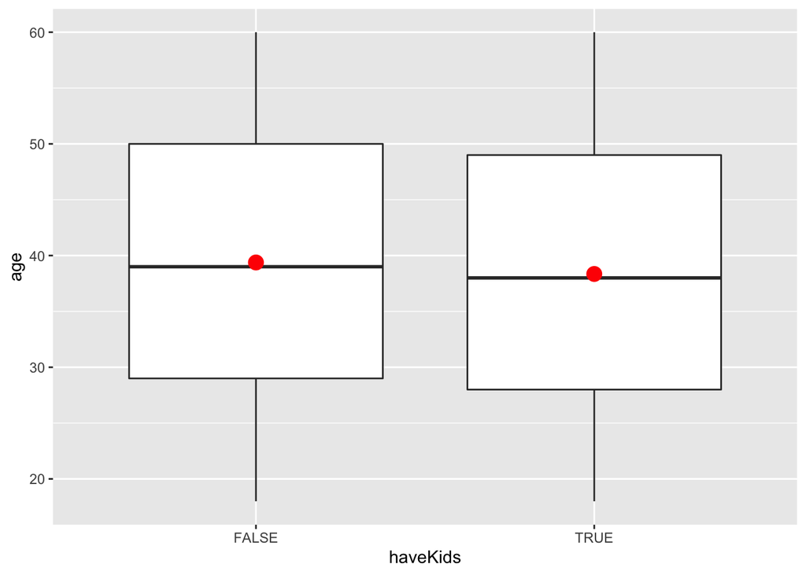

```r
table=table
ggplot(data=participants_data,
       aes(y = age, x= haveKids)) +
  geom_boxplot() +
  geom_point(stat="summary",
             fun.y="mean",
             colour ="red",
             size=4)
```

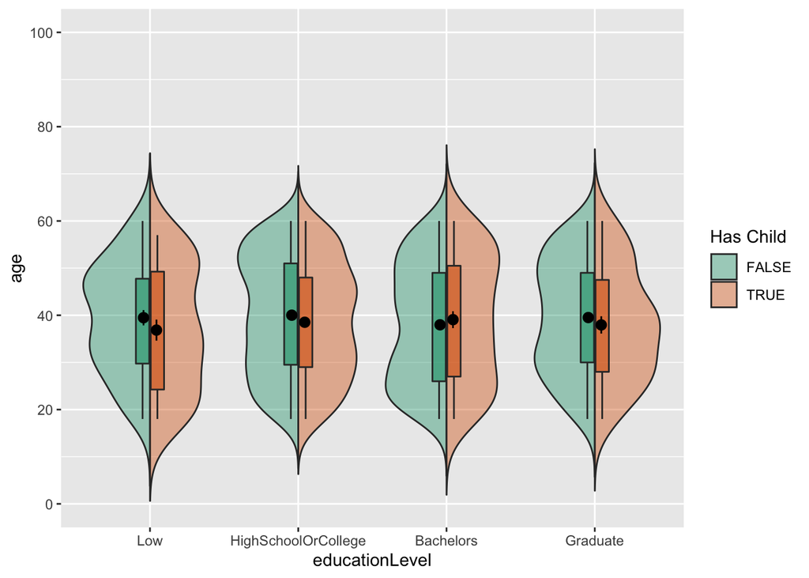

```r
devtools::install_github("psyteachr/introdataviz")
ggplot(participants_data,
       aes(x = educationLevel,
           y = age,
           fill = haveKids)) +
  introdataviz::geom_split_violin(alpha = .4,
                                  trim = FALSE) +
  geom_boxplot(width = .2,
               alpha = .6,
               fatten = NULL,
               show.legend = FALSE) +
  stat_summary(fun.data = "mean_se",
               geom = "pointrange",
               show.legend = F,
               position = position_dodge(.175)) +
  scale_y_continuous(breaks = seq(0, 100, 20),
                      limits = c(0, 100)) +
  scale_fill_brewer(palette = "Dark2",
                    name = "Has Child")
```

```r
participants_data$age_state = ifelse(
    test = participants_data$age > 30,
    yes = "Old",
    no = "Young"
)
# Make it a factor
participants_data$age_state = factor(
    participants_data$age_state,
    levels = c("Old", "Young")
)
```

# Young people tend to be happier than old people.

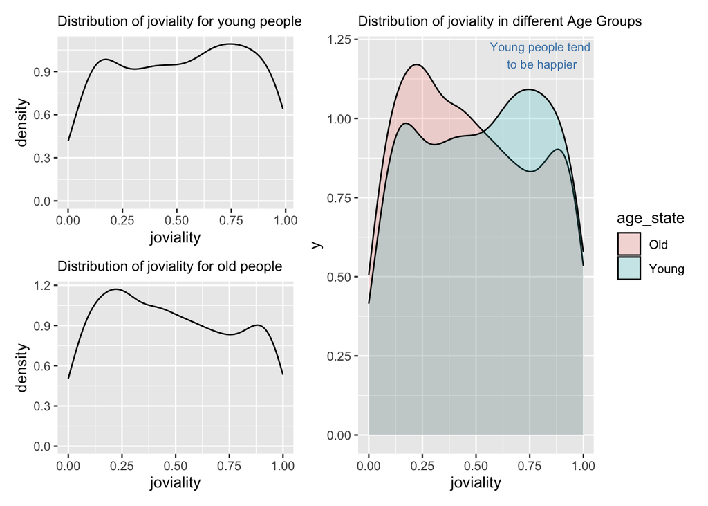

```r
p1 = ggplot(data=subset(participants_data,age_state=='Young'),
       aes(x = joviality)) +
  geom_density() +
  ggtitle("Distribution of joviality for young people")+
  theme(plot.title = element_text(size = 10))
p2 = ggplot(data=subset(participants_data,age_state=='Old'),
       aes(x = joviality)) +
  geom_density() +
  ggtitle("Distribution of joviality for old people")+
  theme(plot.title = element_text(size = 10))
p3 = ggplot(data=participants_data,
aes(x= joviality,
fill = age_state)) +
geom_density(alpha=0.2) +
  annotate("text", x = 0.8, y = 1.2, label = "Young people tend\n to be happier",size=3,color='#4682B4') +
  ggtitle("Distribution of joviality in different Age Groups")+
  theme(plot.title = element_text(size = 10))
(p1 / p2) | p3
```

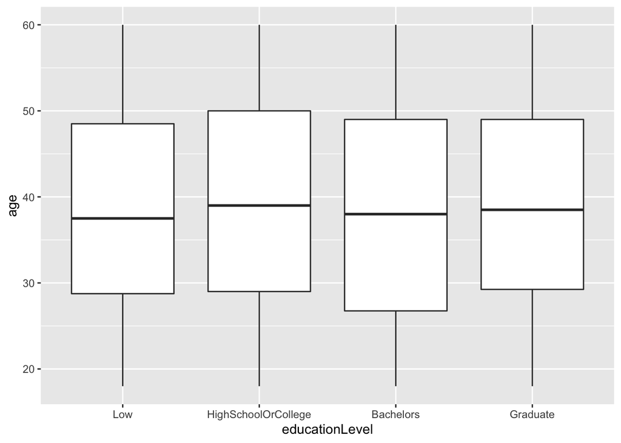

```r
ggplot(data=participants_data,
aes(y = age,
x= educationLevel)) +
geom_boxplot()
```

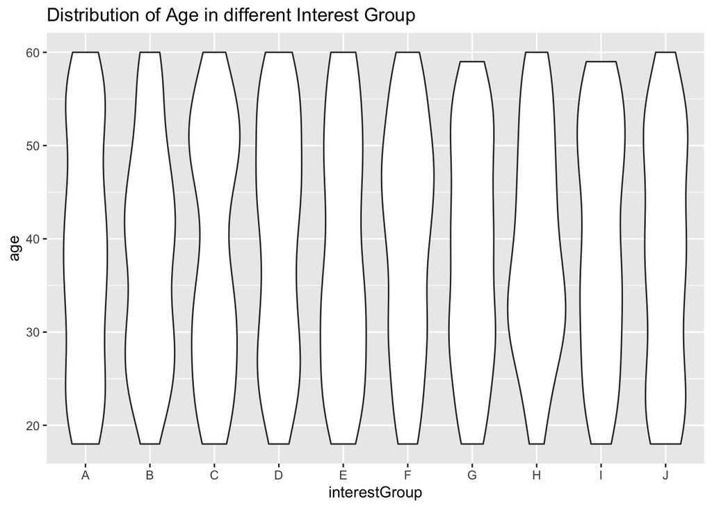

```r
ggplot(data=participants_data,
aes(y = age,x= interestGroup)) +geom_violin()+
ggtitle("Distribution of Age in different Interest Group")
```